# CREAM Finance BAD/GOOD challenge

Dmytro Dudenko

27 Januar 2017

## R Markdown

booting all libraries. Not all of them I need, though.

```r
#Not all of them I need. But I can spontaneously need them.
#So, I keep them all together
library(doParallel); library(parallel)
cores=detectCores()
clust = makeCluster(cores)
registerDoParallel(clust)
library(caret); library(kernlab); library(ISLR); library(RANN);library(plyr);
library(DMwR);library(MASS); library(randomForest); library(rpart);
library(httr);library(iptools);library(CORElearn);library(xml2)
library(scrapeR);library(cluster);library(graphics);library(ggplot2)
```

```r
#reading the data after scraping DNS-RBL data.
#setwd("Schreibtisch/Data_Science_ROOT/JOB-Interviews/CREAM_Finance/")
qq = read.csv(file="train_v3_blended_v2.csv", header = TRUE, fill=TRUE, sep = ';', na.strings = c(""))

#shaping a bit. From now we will work only with IPv4. Land is PL. The rest of data is minor.
#A few countries: GB,NL...all GOOD. No point to consider them.
qq = qq[qq$Income < 4700.0 & qq$Income > 500.0 & qq$IPv4 == 1 & qq$country == "PL",]

#Trying to creat some combined features
qq$DA = (qq$Database_negative+1.0)*qq$Age
qq$DAA = (qq$Database_negative+1.0)*qq$Age*qq$Age
qq$DDA = qq$Database_negative*(qq$Database_negative+1.0)*qq$Age
qq$DDAA = qq$Database_negative*(qq$Database_negative+1.0)*qq$Age*qq$Age
qq$DI = (qq$Database_negative+1.0)*qq$Income
qq$AI = qq$Age*qq$Income
qq$DAI = (qq$Database_negative+1.0)*qq$Age*qq$Income
qq$DA_1 = (qq$Database_negative+1.0)/qq$Age
qq$DI_1 = (qq$Database_negative+1.0)/qq$Income
qq$AI_1 = qq$Age/qq$Income

#one more feature. Number of occurence in four by me selected blacklisted.
qq$RBL_cumulus = (qq$barracuda_response_score == "listed") + (qq$spamrats_response_score == "listed") +
    (qq$sorbs_response_score == "listed") + (qq$apews_org_response_score == "listed")

table(qq$target)
```

```
##
##  BAD GOOD
##  511 4761
```

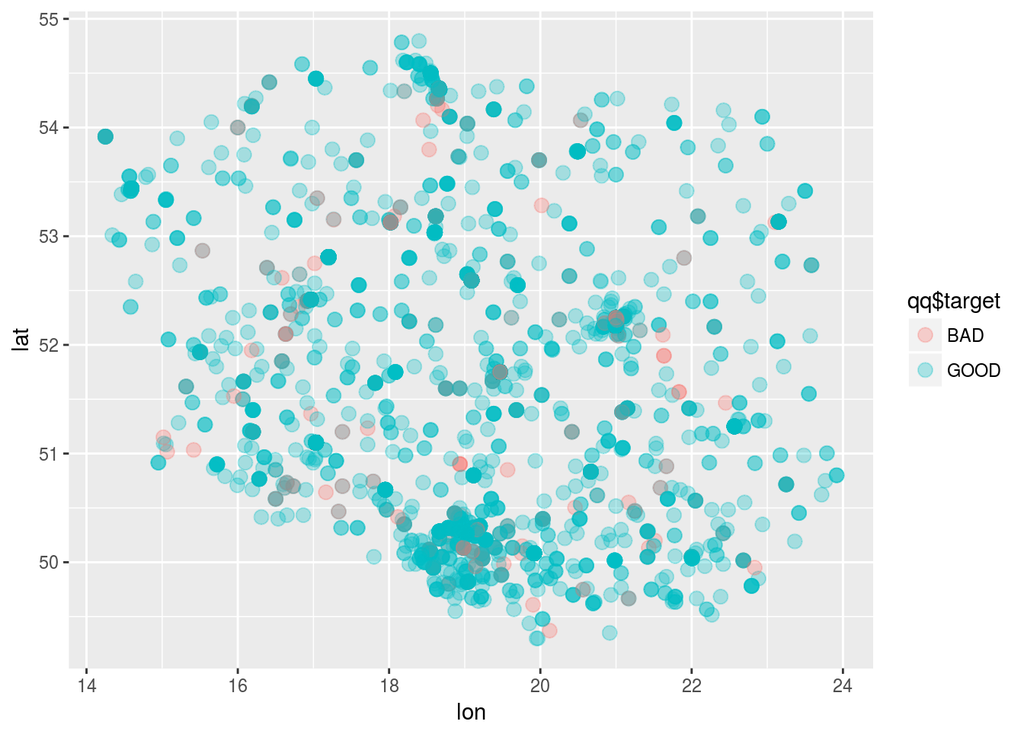

```r
#Our dataset is skewed and therefore needs to be balanced =>downsampled

set.seed(777)
qq_down = downSample(qq[,!names(qq) %in% "target"], qq$target, yname = "target")
```

As it can be seen, there is no distinct geo feature in BAD/GOOD data. GOOD and BAD customers are all smeared over the entire country with respect to polish density of population, mainly centered in Warsaw, Lodz, Krakow/Katowice, Wroclaw, Posnan, and “Trojmiasto” (Gdynia,Sopot,Gdansk). It is also worth of mentioning that geo-data may vary from the true customer location. Main ISP companies are tunneling internet traffic through their gateways, which are often not in the same place as corresponding customers. Therefore, there is no meaning to stick to lon/lat data from RIPE unless true Geoloc data (GPS,Google positioning) is available. So, from numeric point of view, let’s focus mainly in Database_negative, Age, Income and their derivatives

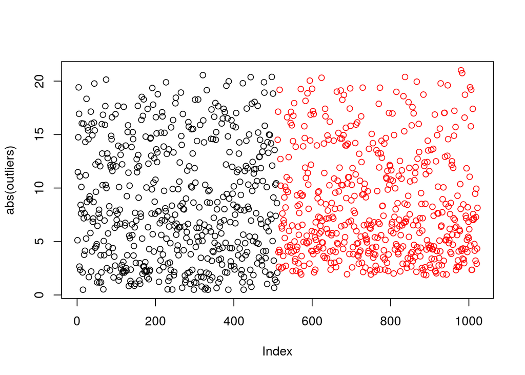

```r
qq_down = dplyr::select(qq_down,Database_negative,Age,Income,DA,DAA,DDA,DDAA,DI,AI,DAI,DA_1,DI_1,AI_1,
                    target)
#Outliers
set.seed(777)
md <- CoreModel(target ~ ., qq_down, model="rf", rfNoTrees=30, maxThreads=1)
outliers <- rfOutliers(md, qq_down)
```

The dataset is very incoherent, a half of data is outlier.

```
##
##     BAD GOOD
##   1 299  207
##   2  46   93
##   3 149  186
##   4  17   25
```

Now we will do a cheat. Removing some of the outliers.

```r
borderline = abs(outliers) < 10

qq_down_v2 = qq_down[borderline,]

set.seed(777)
iTrain = createDataPartition(y=qq_down_v2$target, p=0.8, list = FALSE)

qq_train = qq_down_v2[iTrain,]
qq_test = qq_down_v2[-iTrain,]

control <- trainControl(method="cv", number=10, repeats=5, classProbs = TRUE)

set.seed(777)
model_RF = train(target~., data=qq_train, method="rf", preProcess="range", trControl=control, tuneGrid = expand.grid(.mtry = 2:6),  n.tree=200, maxit=2000, importance=TRUE, proximity=TRUE)

PREDICTION_RF = predict(model_RF, newdata=qq_test)
```

```
## Confusion Matrix and Statistics
##
##           Reference
## Prediction BAD GOOD
##       BAD   57    9
##       GOOD   6   60
##
##                Accuracy : 0.8864
##                  95% CI : (0.8195, 0.935)
##     No Information Rate : 0.5227
##     P-Value [Acc > NIR] : <2e-16
##
##                   Kappa : 0.7727
##  Mcnemar's Test P-Value : 0.6056
##
##             Sensitivity : 0.9048
##             Specificity : 0.8696
##          Pos Pred Value : 0.8636
##          Neg Pred Value : 0.9091
##              Prevalence : 0.4773
##          Detection Rate : 0.4318
##    Detection Prevalence : 0.5000
##       Balanced Accuracy : 0.8872
##
##        'Positive' Class : BAD
##
```

So, accuracy of 0.89 is not that bad. But it is cheating…

```
## rf variable importance
##
##                   Importance
## AI_1                  100.00
## AI                     81.59
## Income                 73.61
## Age                    67.06
## DI_1                   66.54
## DA_1                   64.30
## DAI                    62.74
## DI                     59.27
## DAA                    54.21
## DA                     51.65
## DDA                    38.01
## DDAA                   34.38
## Database_negative       0.00
```

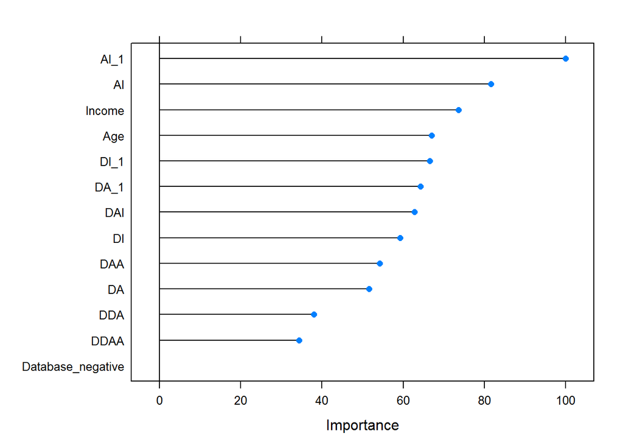

Some derivatives turned out to be even more important than their parent features. Let’s see what other methods can do with it data (averaged NN, GLM, and KNN)

```r
set.seed(777)
model_NN = train(target~., data=qq_train, method="avNNet", preProcess="range", tuneLength=2, maxit = 2000, trControl=control, importance=TRUE)

PREDICTION_NN = predict(model_NN, newdata=qq_test)
```

```
## Confusion Matrix and Statistics
##
##           Reference
## Prediction BAD GOOD
##       BAD   47    8
##       GOOD  16   61
##
##                Accuracy : 0.8182
##                  95% CI : (0.7417, 0.8799)
##     No Information Rate : 0.5227
##     P-Value [Acc > NIR] : 1.305e-12
##
##                   Kappa : 0.6336
##  Mcnemar's Test P-Value : 0.153
##
##             Sensitivity : 0.7460
##             Specificity : 0.8841
##          Pos Pred Value : 0.8545
##          Neg Pred Value : 0.7922
##              Prevalence : 0.4773
##          Detection Rate : 0.3561
##    Detection Prevalence : 0.4167
##       Balanced Accuracy : 0.8150
##
##        'Positive' Class : BAD
##
```

Accuracy 0.82. Not that bad either. Obviously, if we could cut more outliers, it would be higher. Although, it would be a hardcore cheating…

```r
knnGrid <- expand.grid(.k=c(2:50))

set.seed(777)
model_knn <- train(target ~ ., data = qq_train,
                   method = "knn",                  preProcess = c("center", "scale"),
                   tuneLength = 20, tuneGrid =knnGrid,
                   trControl=control)

PREDICTION_knn = predict(model_knn, newdata=qq_test)
```

[output not shown]

Accuracy 0.87. Very good.

Now let’s have a look at the features. How do their correlate with each other.

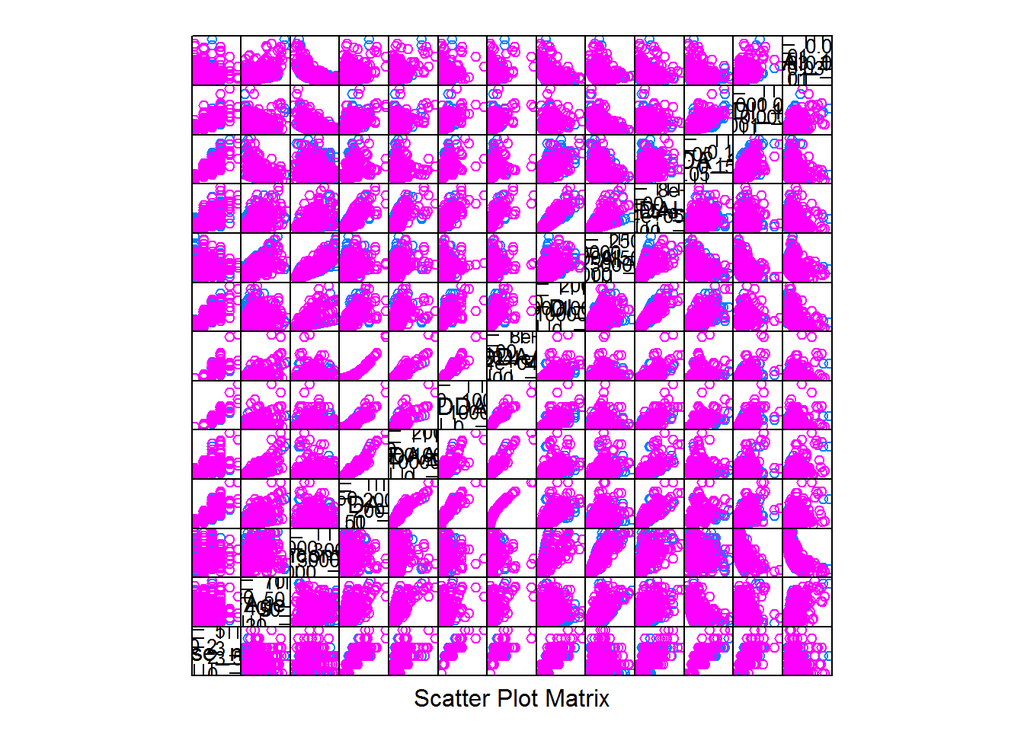

So, eventhough we have done some cheating, features didn’t start showing correlating patterns. I assume that nature of BAD/GOOD labeling is not mainly based in Age/Income, rather on specific fingerprints of IPs. Let’s include them in our model.

```r
set.seed(777)
qq_down2 = downSample(qq[,!names(qq) %in% "target"], qq$target, yname = "target")

qq_down2 = dplyr::select(qq_down2,Database_negative,Age,Income,DA,DAA,DDA,DDAA,DI,AI,DAI,DA_1,DI_1,AI_1,
                        barracuda_response_score,spamrats_response_score,sorbs_response_score,apews_org_response_score,
                        RBL_cumulus,target)
```

So, removing outliers again

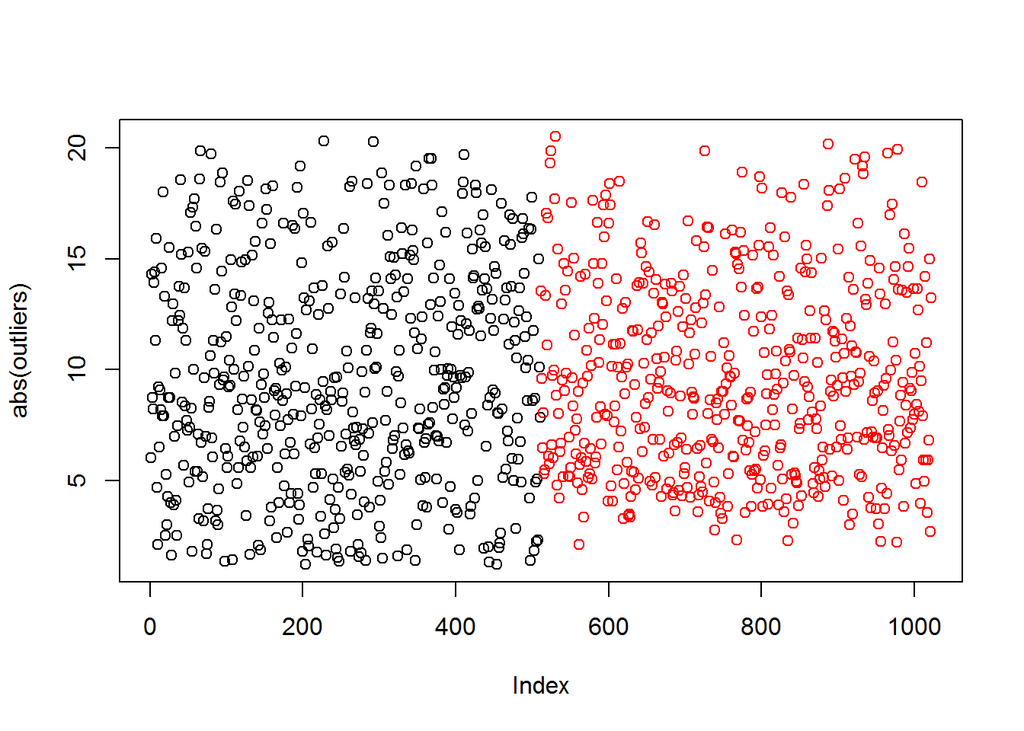

```r
#Outliers

set.seed(777)
md <- CoreModel(target ~ ., qq_down2, model="rf", rfNoTrees=30, maxThreads=1)
outliers <- rfOutliers(md, qq_down2)
```

The very similar picture, a half of data is outlier. Meaning that the labeling is not based on our set of features.

```r
borderline = abs(outliers) < 10

qq_down2_v2 = qq_down2[borderline,]

set.seed(777)
iTrain = createDataPartition(y=qq_down2_v2$target, p=0.8, list = FALSE)

qq_train2 = qq_down2_v2[iTrain,]
qq_test2 = qq_down2_v2[-iTrain,]


control <- trainControl(method="cv", number=10, repeats=5, classProbs = TRUE)

set.seed(777)
model_RF2 = train(target~., data=qq_train2, method="rf", preProcess="range", trControl=control, tuneGrid = expand.grid(.mtry = 2:6),  n.tree=200, maxit=2000, importance=TRUE, proximity=TRUE)

PREDICTION_RF2 = predict(model_RF2, newdata=qq_test2)
```

```
## Confusion Matrix and Statistics
##
##           Reference
## Prediction BAD GOOD
##       BAD   52    3
##       GOOD   5   57
##
##                Accuracy : 0.9316
##                  95% CI : (0.8697, 0.97)
##     No Information Rate : 0.5128
##     P-Value [Acc > NIR] : <2e-16
##
##                   Kappa : 0.863
##  Mcnemar's Test P-Value : 0.7237
##
##             Sensitivity : 0.9123
##             Specificity : 0.9500
##          Pos Pred Value : 0.9455
##          Neg Pred Value : 0.9194
##              Prevalence : 0.4872
##          Detection Rate : 0.4444
##    Detection Prevalence : 0.4701
##       Balanced Accuracy : 0.9311
##
##        'Positive' Class : BAD
##
```

So, accuracy of 0.93 is better than 0.89, which was achieved by not considering blacklists. But still, it is cheating…

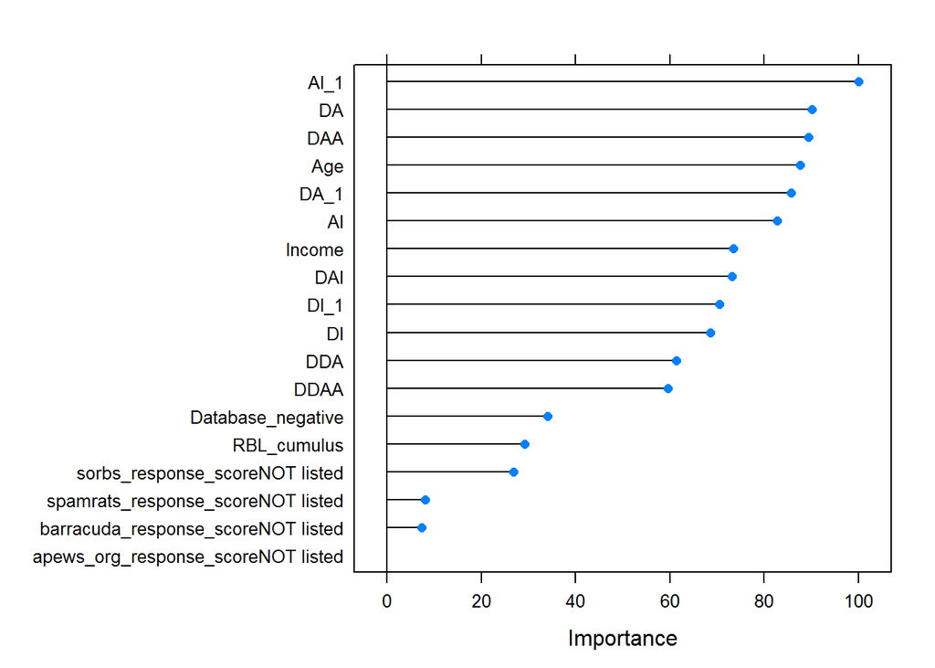

So, we see that sorbs.net did help a bit to improve our model. Although, the most important features are still our numerical derivatives.

```r
set.seed(777)
model_NN2 = train(target~., data=qq_train2, method="avNNet", preProcess="range", tuneLength=2, maxit = 2000, trControl=control, importance=TRUE)

PREDICTION_NN2 = predict(model_NN2, newdata=qq_test2)
```

```
## Confusion Matrix and Statistics
##
##           Reference
## Prediction BAD GOOD
##       BAD   49    7
##       GOOD   8   53
##
##                Accuracy : 0.8718
##                  95% CI : (0.7974, 0.9264)
##     No Information Rate : 0.5128
##     P-Value [Acc > NIR] : <2e-16
##
##                   Kappa : 0.7433
##  Mcnemar's Test P-Value : 1
##
##             Sensitivity : 0.8596
##             Specificity : 0.8833
##          Pos Pred Value : 0.8750
##          Neg Pred Value : 0.8689
##              Prevalence : 0.4872
##          Detection Rate : 0.4188
##    Detection Prevalence : 0.4786
##       Balanced Accuracy : 0.8715
##
##        'Positive' Class : BAD
##
```

Averaged Neural Network has also improved. From 0.82 to 0.87.

Let’s check KNN.

```r
knnGrid <- expand.grid(.k=c(2:50))

set.seed(777)
model_knn2 <- train(target ~ ., data = qq_train2,
                   method = "knn",                  preProcess = c("center", "scale"),
                   tuneLength = 20, tuneGrid =knnGrid,
                   trControl=control)

PREDICTION_knn2 = predict(model_knn2, newdata=qq_test2)
```

```
## Confusion Matrix and Statistics
##
##           Reference
## Prediction BAD GOOD
##       BAD   42    7
##       GOOD  15   53
##
##                Accuracy : 0.812
##                  95% CI : (0.7293, 0.8782)
##     No Information Rate : 0.5128
##     P-Value [Acc > NIR] : 1.688e-11
##
##                   Kappa : 0.6224
##  Mcnemar's Test P-Value : 0.1356
##
##             Sensitivity : 0.7368
##             Specificity : 0.8833
##          Pos Pred Value : 0.8571
##          Neg Pred Value : 0.7794
##              Prevalence : 0.4872
##          Detection Rate : 0.3590
##    Detection Prevalence : 0.4188
##       Balanced Accuracy : 0.8101
##
##        'Positive' Class : BAD
##
```

Great, KNN did a bit of drop from 0.87 to 0.81. Hence, we should work towards tuning our blacklist and cumulated scoring based on those lists.